# Scare-off measures against wild boars

computational movement analysis

Lia Baumann and Michele Senn

## Introduction

#Step 1 To find out, which boars were affected by which Schreck, the datasets were both transformed into the same coordinate system using st_transform(2056). They were subsequently plotted on top of each other to visualize the spatial overlap.

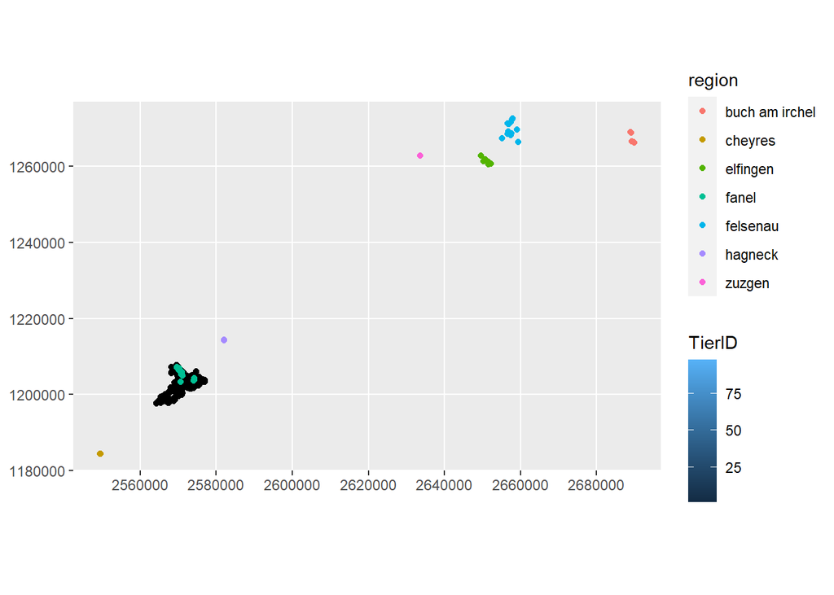

As a result, it was found that the animals were only tracked around the Schreck in the region of Fanel. As a consequence, all other Schreck data points were removed and the spatial overlap replotted.

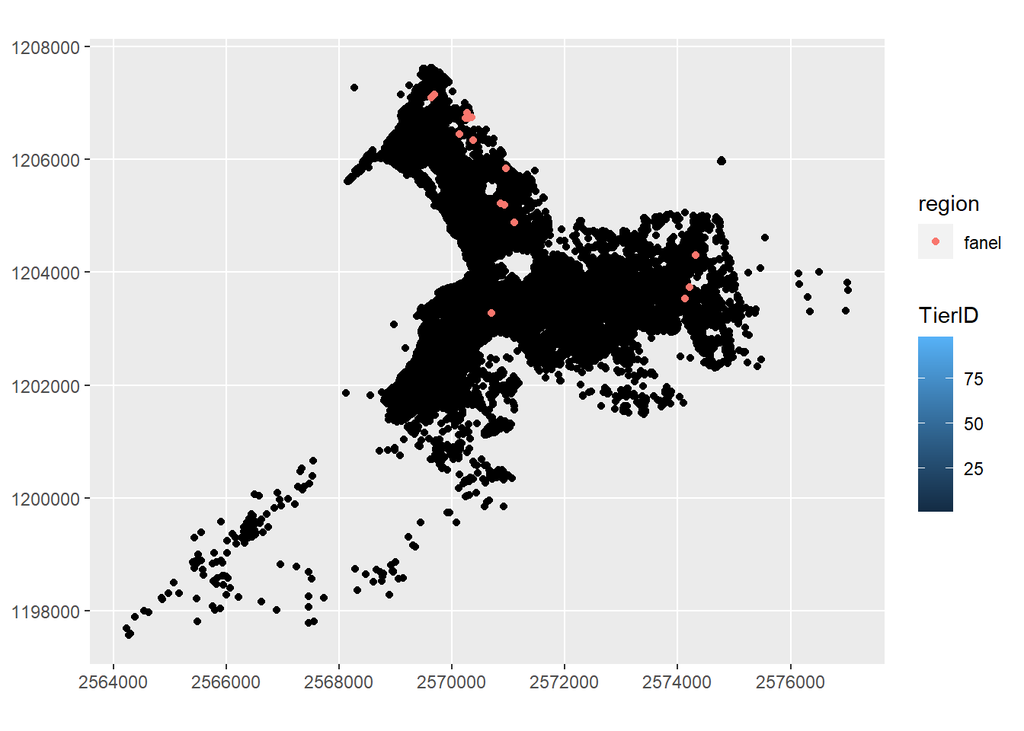

#Step 2

In order to combine the data about the Schreck locations and their corresponding agenda, or sounding time, they were joined by their matching column “id” with an inner join. Following this join, the agenda of all the “Schreck time” was visualized using an errorbar plot.

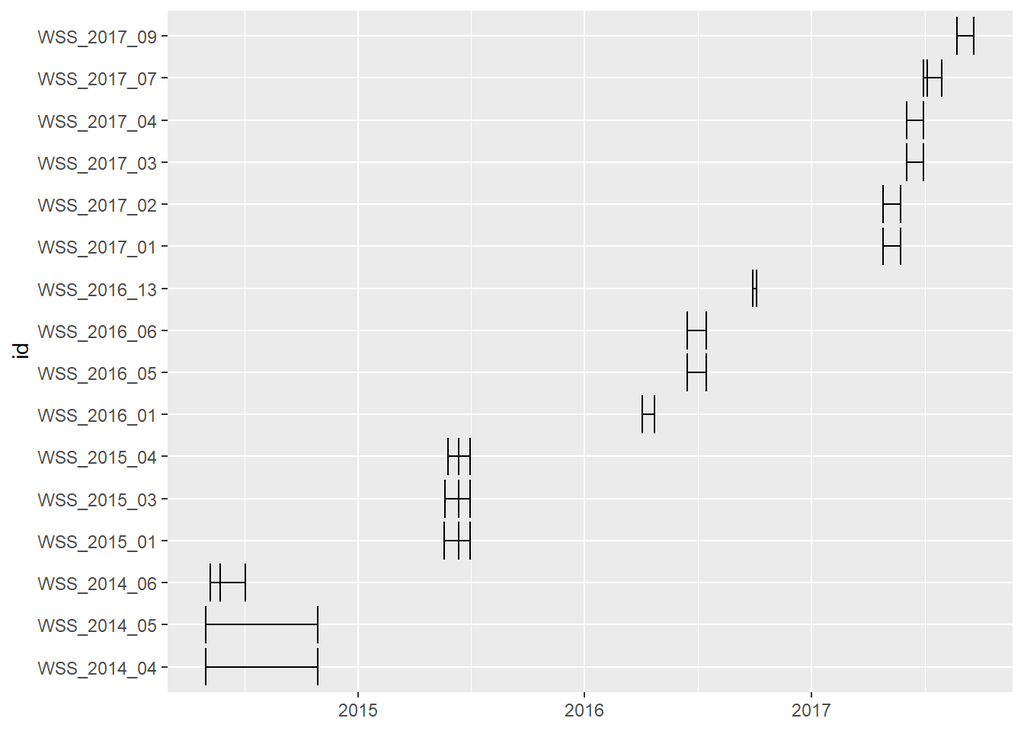

# Step 3

In order to understand which animals were active during the period of “Schreck time”, the boar data was filtered by the dates in which the first Schreck (WSS_2014_04) was active. For the affected boars, a distance between their coordinates and the Schreck coordinate could be calculated using st_distance(). For a reduction in data points, all distances bigger than 2000m were removed. The remaining distances were plotted against the DatetimeUTC column. 5 animals were close to Schreck 1 during “Schreck time”.

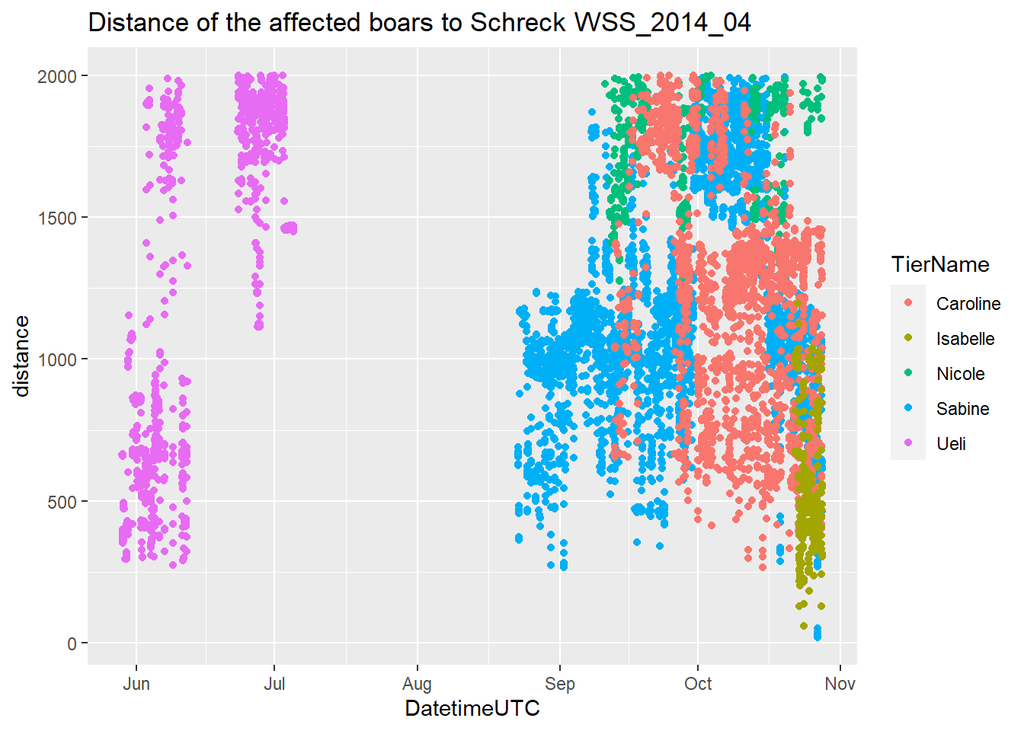

#Step 4 Ueli looks like an interesting candidate for further inspection. His corresponding location data to “Schreck time 1” were filtered and visualized in different ways.

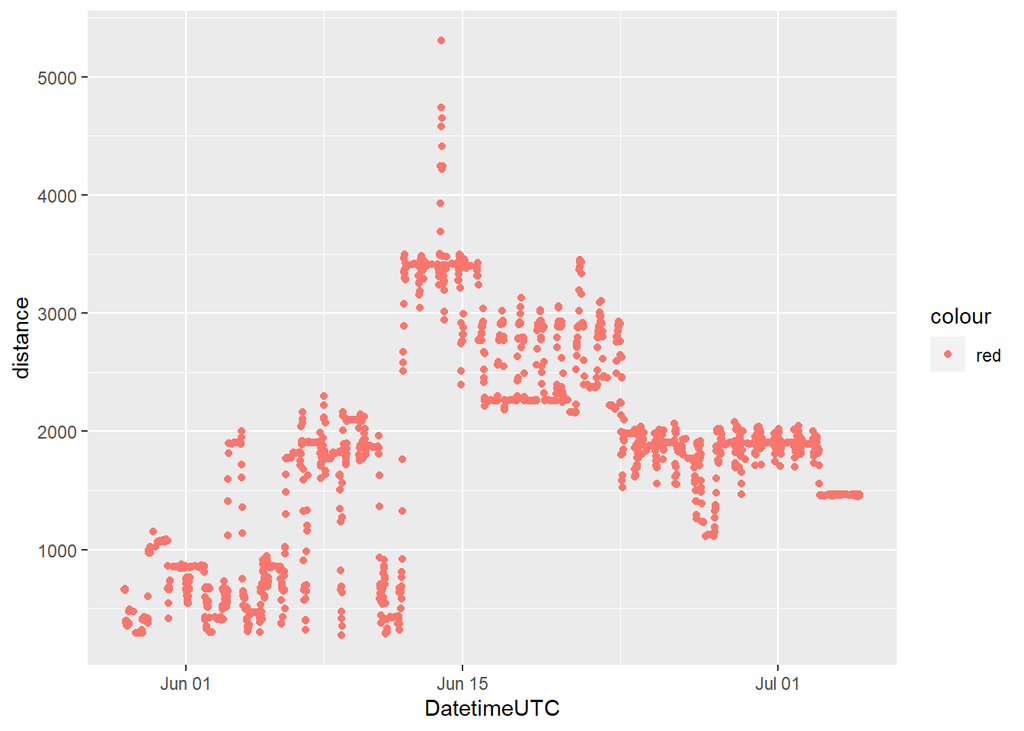

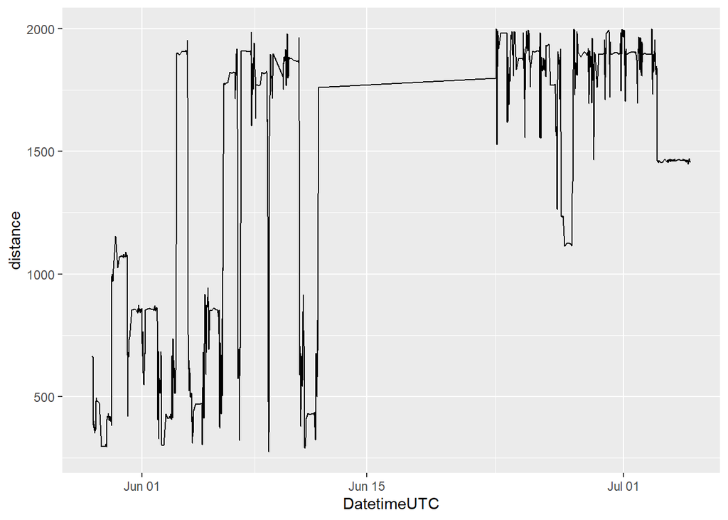

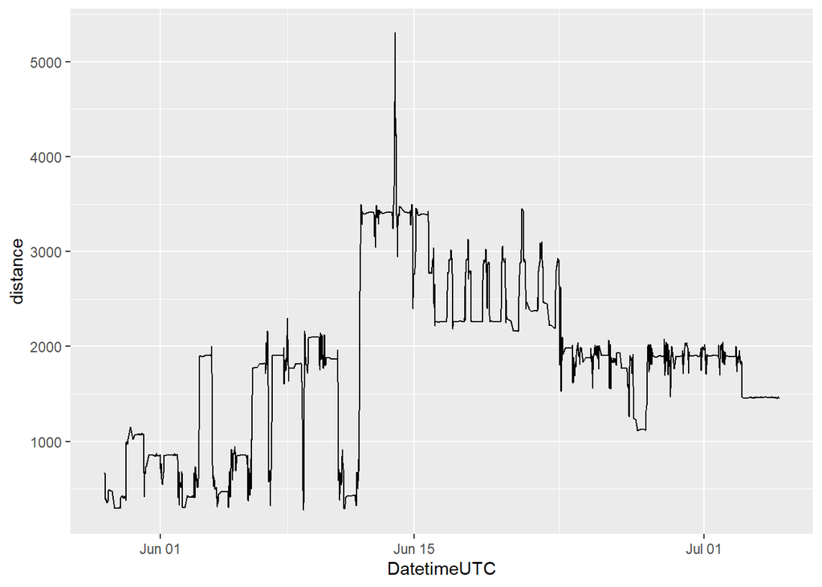

#Step 5 The other animals around Schreck 1 seemed to move in a different way. In order to see more of it, a facet grid was created. To increase resolution and to show only the concurrently affected boars, Ueli was filtered out in a second facet grid visualization.

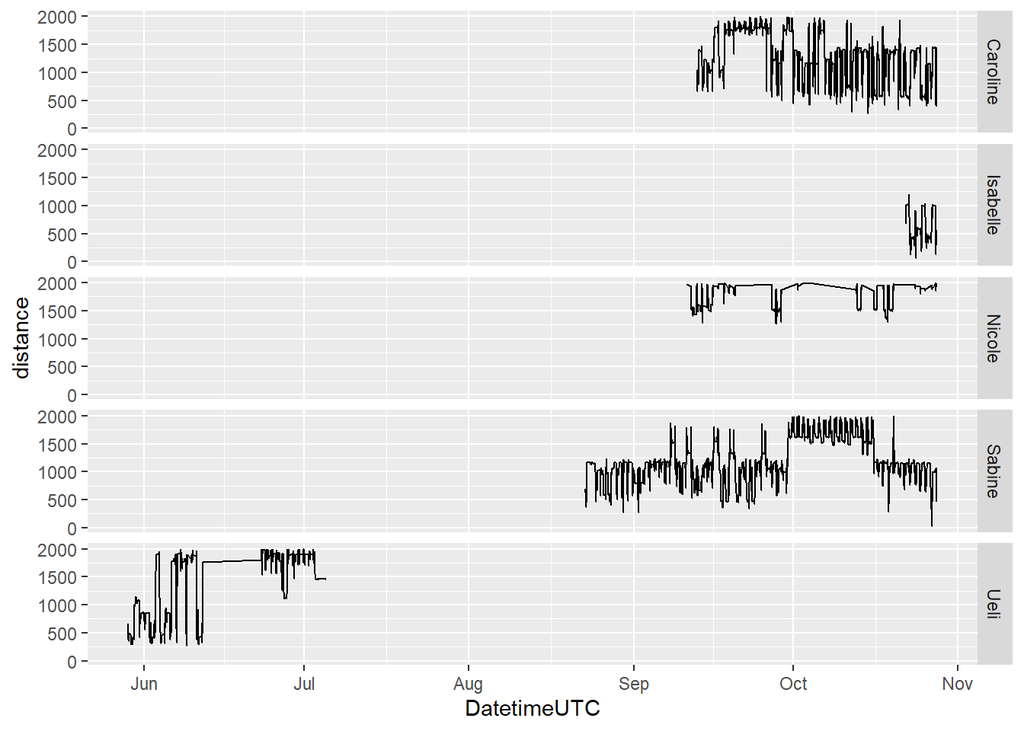

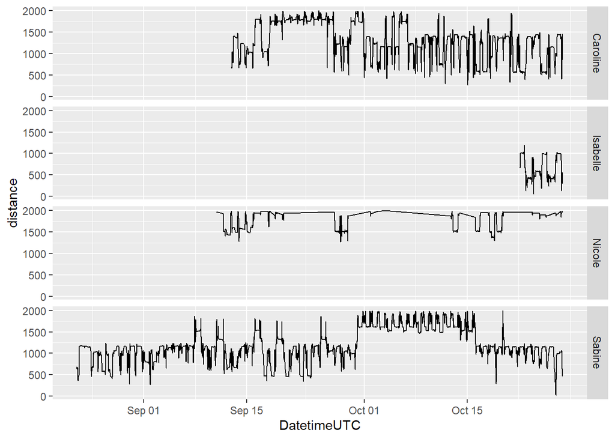

#Step 5 Now, looking at the distances of Schreck 1 was interesting. Since we are trying to find general patterns (if possible) and later want to look at the returning patterns, all other Schrecks are about to be visualized in a similar fashion.

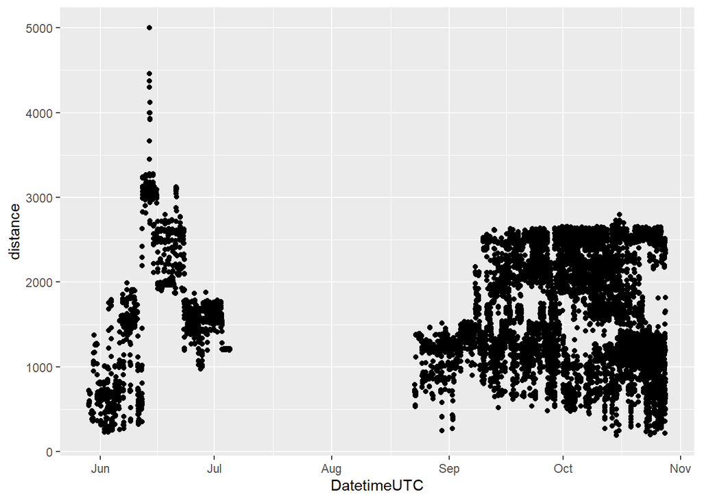

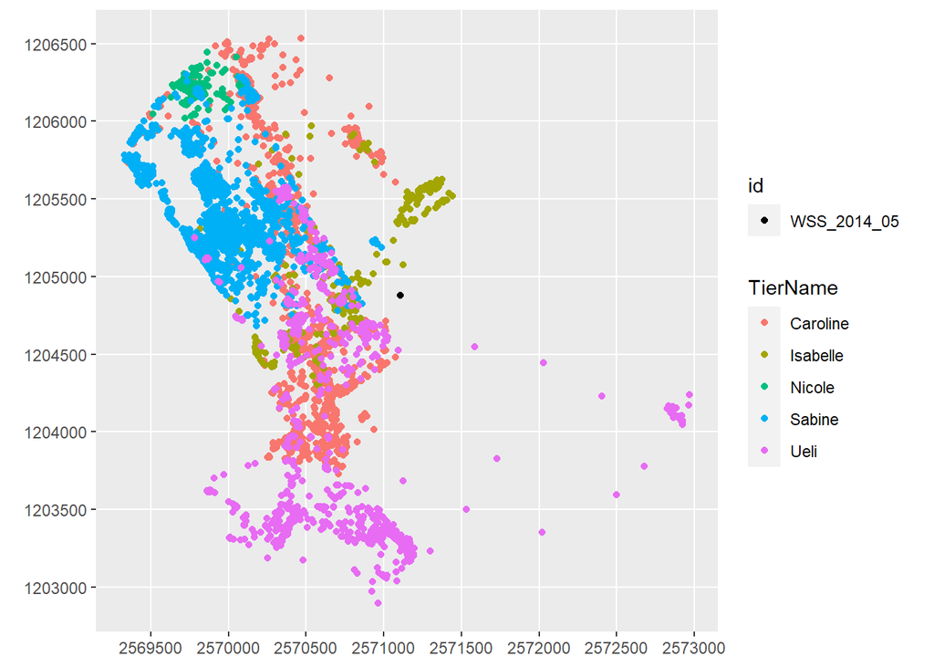

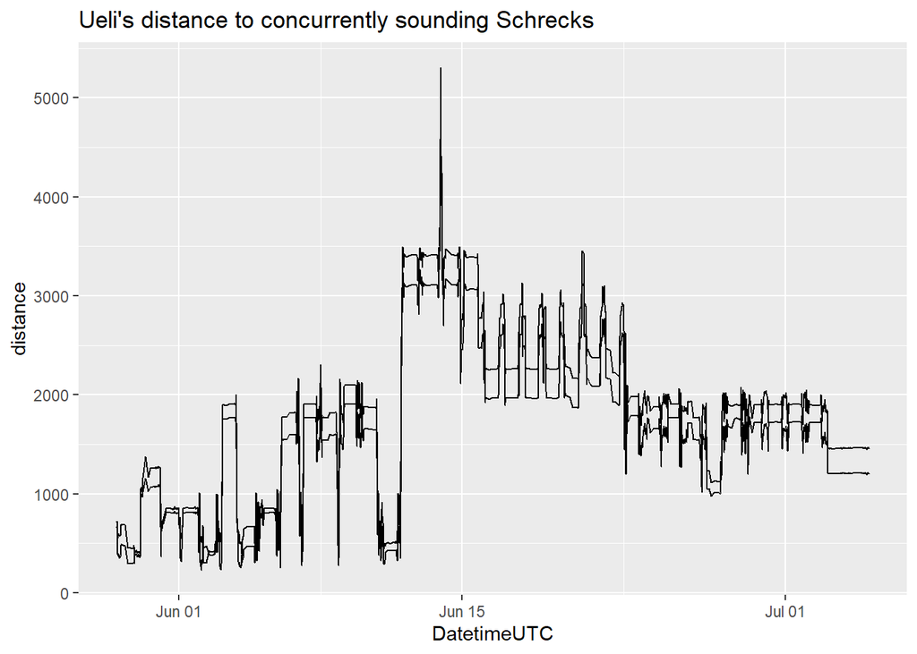

# Step 6

As a measure to reduce data point density, only every 50th observation was used. The loss in data granularity has an effect for readability and observability of a general movement trend, and it doesn’t seem that a lot of the information is lost on the way.

In the following graph, distances from Ueli to the two first Schrecks are visualized with a much lower resolution.

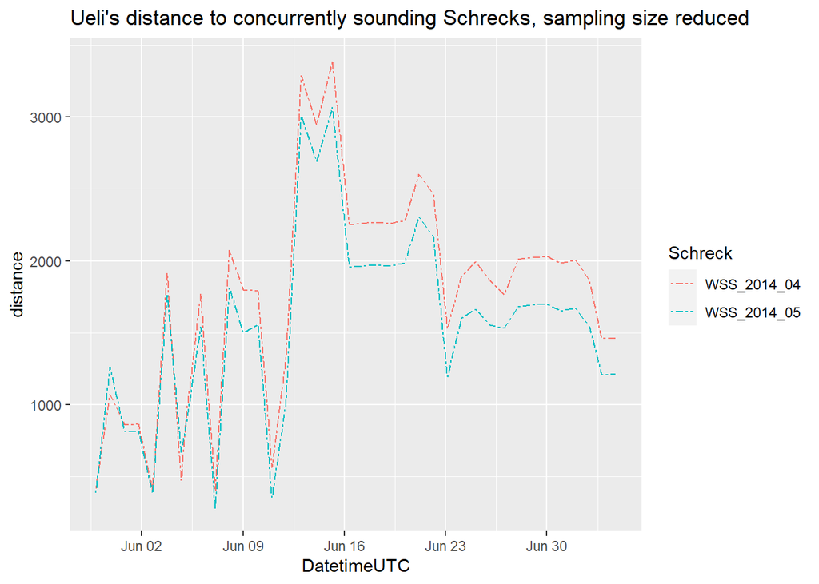

#Step 7 A similar approach was used for the other boars affected by Schreck 1 and 2, but even reducing their data points to every 150th.

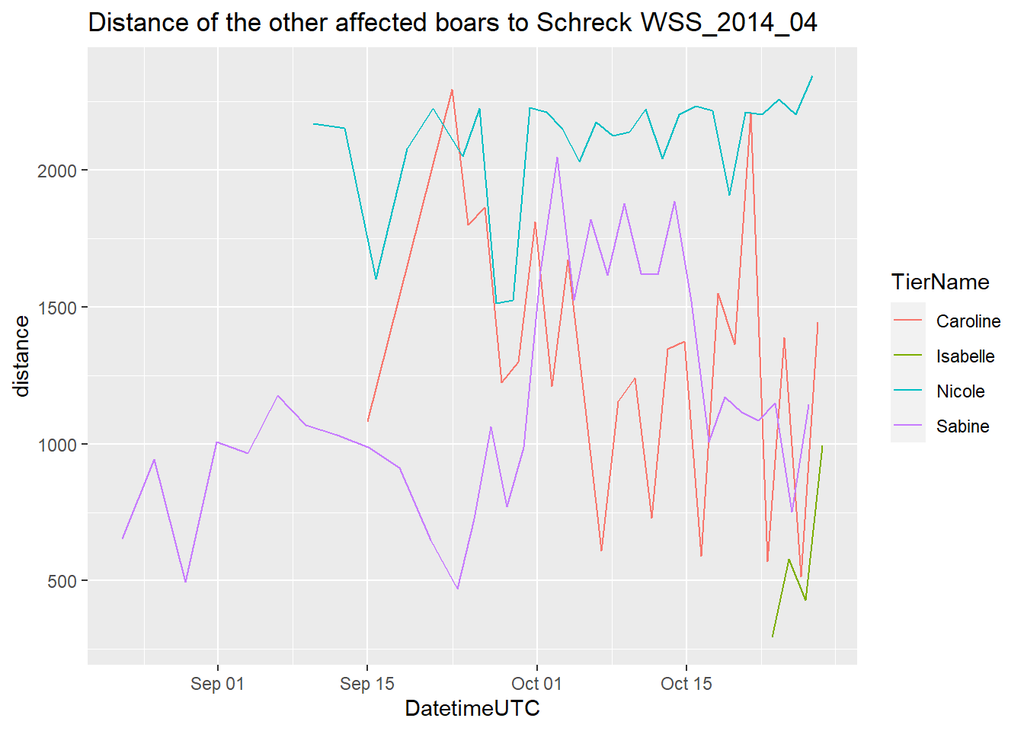

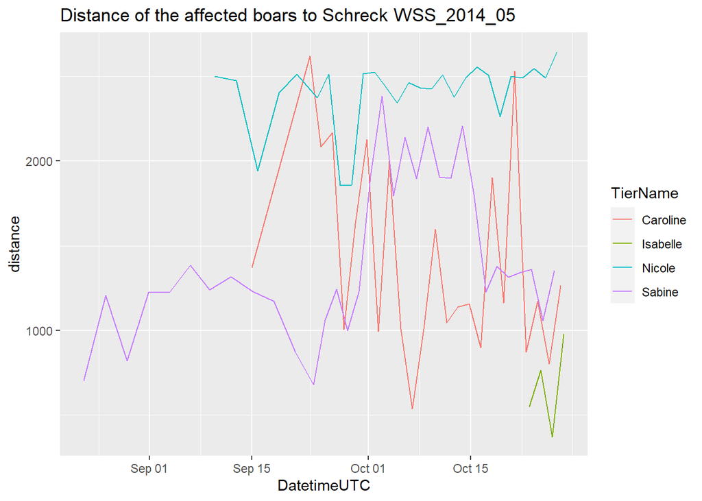

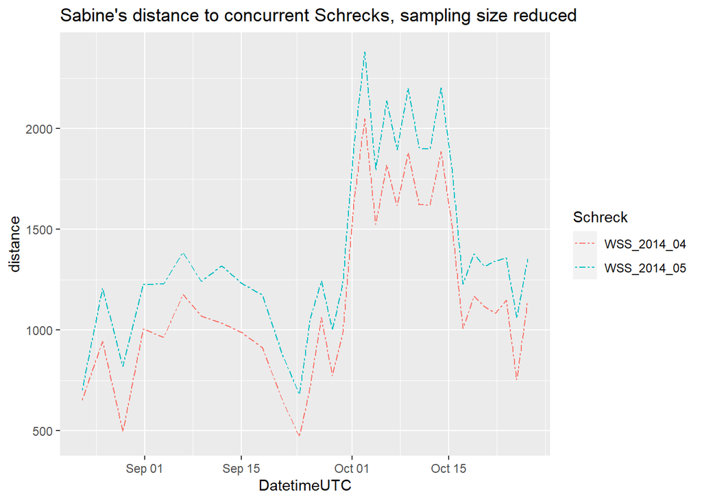

# Step 8

No animal was around at the “Schreck time” of Schreck 3 so it will be omitted for further analyses. Schreck 4 could only affect our friend Ueli so he will be analysed on his own. Apparently, this Schreck was active almost at the same time as Schreck 1 and 2, so all distances to the 3 Schrecks were visualized together for Ueli. It’s almost eerie how similar his distancing behavior looks…

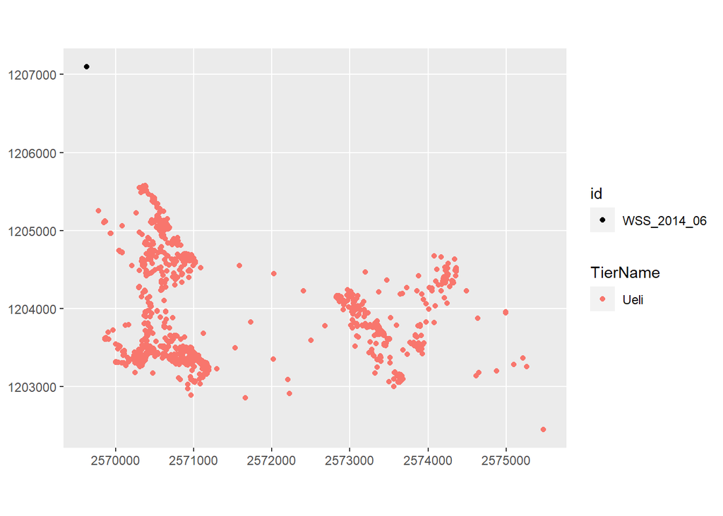

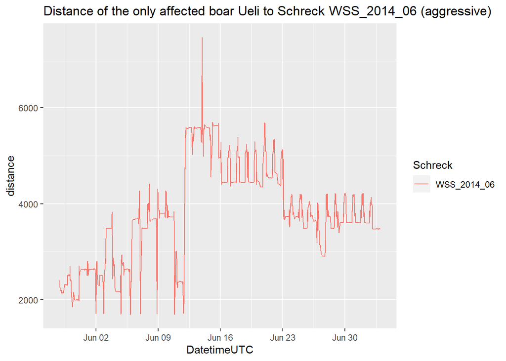

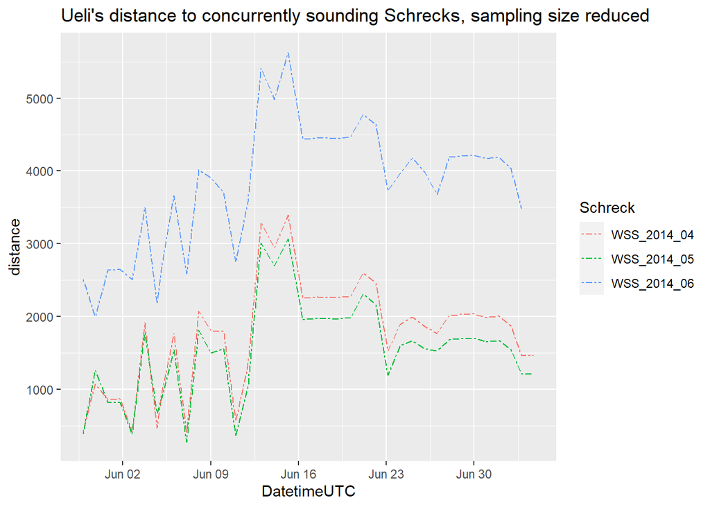

#Step 9 Schreck 5 and 6 are the same but move from standard to aggressive mode. Their distances were visualized with the close animals (ca. <1300m) and only every 50th observation was plotted. The change in mode was visualized using a different line style.

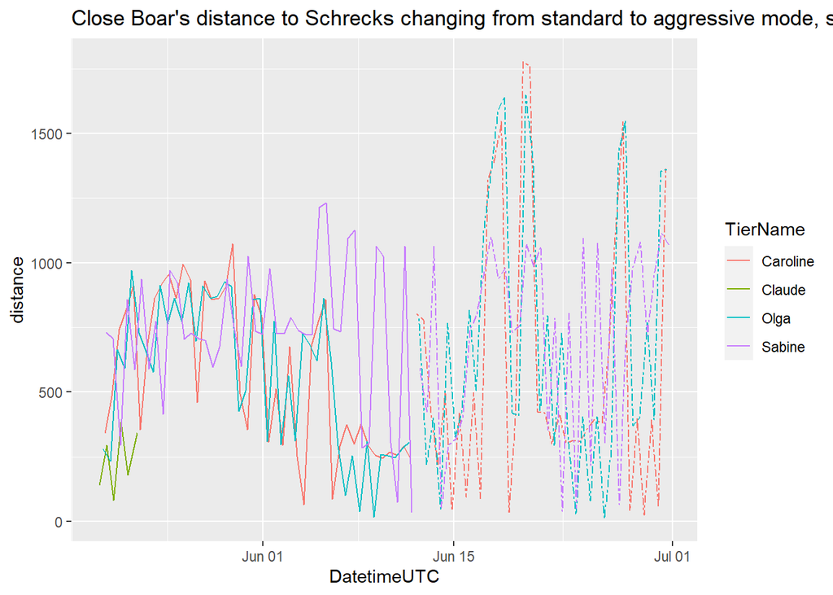

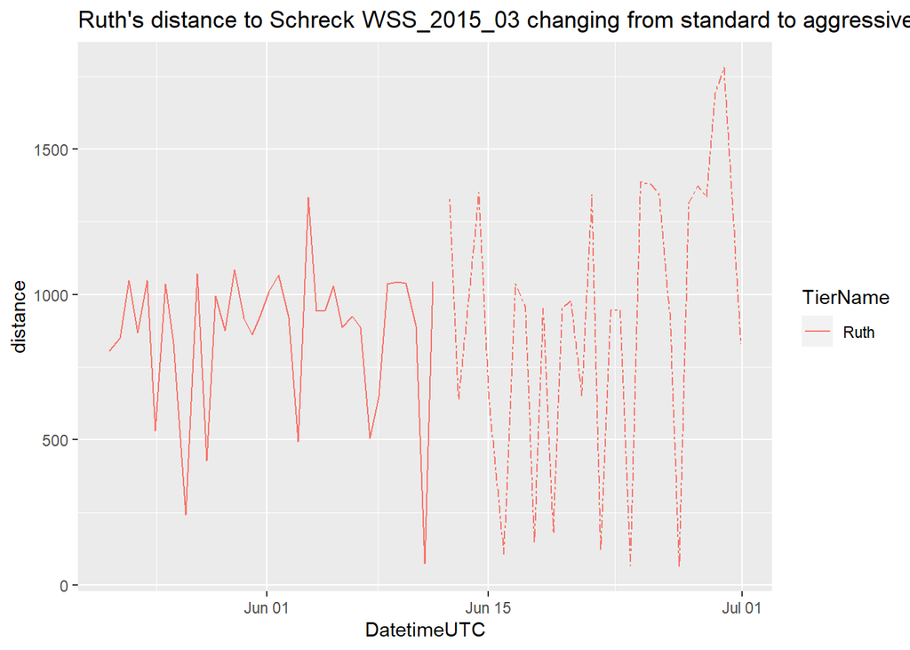

#Step 11

[figure not shown]